# ROS_staining

JY

3/29/2023

```r
library(tidyverse)
library(cowplot)
```

## Goal

Chronic phosphate limitation (>5hr) has been shown to induce cell cycle arrest, manifested as a steady decrease in the percent of cells with buds in *S. cerevisiae*. This coincides with the inductioin of a “general starvation program” that is associated with large changes in metabolism and upregulation of stress responses, including a number of OSR genes (but do not include *CTT1* and *CTA1*). Thus, one hypothesis for the divergent ASR phenotype we observed is that *C. glabrata* enters cell cycle arrest faster than *S. cerevisiae* and the ASR effect we observed is in fact the manifestation of its general starvation program. To test this hypothesis, Chris Youngstrom in the lab did a time course microsopy to quantify the budding index (% of cells with buds) in both species during phosphate starvation.

## Data

The experiments were performed on 2023/04/07, 04/10 and 04/11. Each “replicate” is an independent sample, for which multiple fields of view were counted on a hemotocytomer. We will first sum up the numbers for each replicate and then calculate the percentages. We will ignore the Excel calculated percentages, which were based on individual fields of views.

```r
# import the data
raw <- read_csv("input/20230421-budding-data-clean-HB.csv", col_types = "ccciiii") %>%
  mutate(exp = paste(date, replicate, sep = "-"))
raw %>% group_by(species, exp, time) %>%
  summarize(fileds = n(), total_count = sum(total)) %>%
  arrange(species, exp, time)
```

| species | exp | time | fileds | total_count |
| --- | --- | --- | --- | --- |
| Cg | d040723-R1 | 0 | 4 | 149 |
| Cg | d040723-R1 | 45 | 4 | 433 |
| Cg | d040723-R1 | 90 | 4 | 224 |
| Cg | d040723-R2 | 45 | 4 | 487 |
| Cg | d040723-R2 | 90 | 4 | 262 |
| Cg | d041123-R1 | 0 | 1 | 115 |
| Cg | d041123-R1 | 20 | 4 | 214 |
| Cg | d041123-R1 | 45 | 4 | 209 |
| Cg | d041123-R1 | 75 | 4 | 160 |
| Cg | d041123-R1 | 105 | 4 | 193 |

[output cut: 24 more lines]

check to make sure that the total number of budded and unbudded cells add up to the total cell count

```r
with(raw, all(budded + unbudded == total))
```

```
[1] TRUE
```

sum up the counts from different (mostly 4) fields of view for each sample

```r
bud <- raw %>%
  group_by(date, species, exp, replicate, time) %>%
  summarize(across(c(total, budded, unbudded), sum), .groups = "drop")
bud
```

| date | species | exp | replicate | time | total | budded | unbudded |
| --- | --- | --- | --- | --- | --- | --- | --- |
| d040723 | Cg | d040723-R1 | R1 | 0 | 149 | 118 | 31 |
| d040723 | Cg | d040723-R1 | R1 | 45 | 433 | 293 | 140 |
| d040723 | Cg | d040723-R1 | R1 | 90 | 224 | 78 | 146 |
| d040723 | Cg | d040723-R2 | R2 | 45 | 487 | 308 | 179 |
| d040723 | Cg | d040723-R2 | R2 | 90 | 262 | 81 | 181 |
| d040723 | Sc | d040723-R1 | R1 | 0 | 121 | 83 | 38 |
| d040723 | Sc | d040723-R1 | R1 | 45 | 279 | 145 | 134 |
| d040723 | Sc | d040723-R1 | R1 | 90 | 247 | 166 | 81 |
| d040723 | Sc | d040723-R2 | R2 | 45 | 292 | 146 | 146 |
| d040723 | Sc | d040723-R2 | R2 | 90 | 191 | 122 | 69 |

[output cut: 24 more lines]

In the 04/07 experiment, Chris used the same 0 min sample for both biological replicates – the cultures were split after taking the 0 minute time point. We will duplicate the 0 minute time point data from R1 and use it for R2. Let’s also calculate the percent unbudded and the [binomial proportion confidence interval](https://en.wikipedia.org/wiki/Binomial_proportion_confidence_interval)

```r
subRefDat <- filter(bud, date == "d040723", time == 0) %>%
  mutate(exp = gsub("R1", "R2", exp))
bud1 <- rbind(bud, subRefDat) %>% arrange(species, exp, time) %>%
  mutate(p_unbud = unbudded / total,
         sd = sqrt((p_unbud * (1-p_unbud))/total))
bud1 %>% head()
```

| date | species | exp | replicate | time | total | budded | unbudded | p_unbud | sd |
| --- | --- | --- | --- | --- | --- | --- | --- | --- | --- |
| d040723 | Cg | d040723-R1 | R1 | 0 | 149 | 118 | 31 | 0.2080537 | 0.03325389 |
| d040723 | Cg | d040723-R1 | R1 | 45 | 433 | 293 | 140 | 0.3233256 | 0.02247843 |
| d040723 | Cg | d040723-R1 | R1 | 90 | 224 | 78 | 146 | 0.6517857 | 0.03183110 |
| d040723 | Cg | d040723-R2 | R1 | 0 | 149 | 118 | 31 | 0.2080537 | 0.03325389 |
| d040723 | Cg | d040723-R2 | R2 | 45 | 487 | 308 | 179 | 0.3675565 | 0.02184784 |
| d040723 | Cg | d040723-R2 | R2 | 90 | 262 | 81 | 181 | 0.6908397 | 0.02855156 |

## Plotting

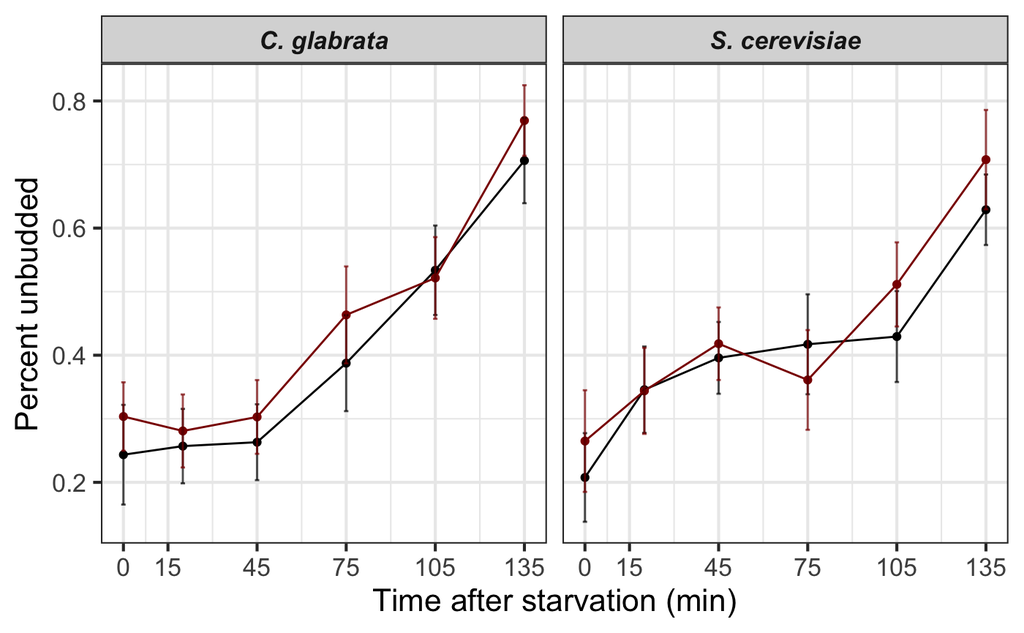

```r
sps <- c("Sc" = "S. cerevisiae", "Cg" = "C. glabrata")

bud1 %>%
  filter(date != "d040723") %>%
  #mutate(time = factor(time, levels = sort(unique(time)))) %>%
  ggplot(aes(x = time, y = p_unbud, group = exp, color = replicate)) +
  geom_point() + geom_line() +
  geom_errorbar(aes(ymin = p_unbud - 1.96*sd, ymax = p_unbud + 1.96*sd,
                    color = replicate), width = 1.5, alpha = 0.7) +
  scale_color_manual(values = c("black", "darkred"), guide = "none") +
  scale_x_continuous(breaks = c(0, 15, 45, 75, 105, 135)) +
  facet_wrap(~species, labeller = labeller(species = sps)) +
  xlab("Time after starvation (min)") + ylab("Percent unbudded") +
  theme_bw(base_size = 16) +
  theme(strip.text = element_text(face = 4))
ggsave("output/20230422-HB-unbudded-timecourse.png", width = 6, height = 4)
```

Statistical test for 45 min data

```r
dat <- filter(bud1, time == 45, date != "d040723") %>%
  group_by(species) %>%
  summarize(across(budded:unbudded, sum)) %>%
  column_to_rownames("species") %>%
  as.matrix()
fisher.test(dat)
```

```
    Fisher's Exact Test for Count Data

data:  dat
p-value = 4.479e-05
alternative hypothesis: true odds ratio is not equal to 1
95 percent confidence interval:
 1.315212 2.268973
sample estimates:
odds ratio
  1.725314
```